# Kusama Analysis

Jonas Gehrlein

6/25/2021

# Introduction

With the launch of crowdloans and parachain auctions, the Kusama network has overall lost significant market capitalization. However, there is a general decline in crypto-currency prices across all coins, which could bias the perception. This analysis aims to analyze different aspects that happened during a 42 days period (between the 2021-05-13 and 2021-06-23). This includes the mid of May where prices were generally high as well as the following decline and the announcement and start of the Kusama auctions.

In this analysis, I focus on market data (prices, market cap and trading volume) of BTC, KSM and some close competitors. Additionally, I incorporate behavioral on-chain data (unstaking decisions and crowdloan contributions). The following questions should be answered:

- What is the current development of the KSM price compared to BTC and close competitors?
- Is the price crash of Kusama more severe than for other tokens?
- Is the decline in the KSM price causally linked to the BTC price or other tokens?
- Can the price development of Kusama be explained by unstaking events (i.e., are coins more likely sold than contributed)?
- How much KSM is contributed to the crowdloans and how is that split between the various teams?
- As an estimate, how many Tokens were unstaked and actually ended up in crowdloans? This also gives some information on how much is still liquid or potentially was sold.

## Overview

| Name | Date | Session_number |
| --- | --- | --- |
| First Day of Analysis | 2021-05-13 | 12748 |
| Last Day of Analysis | 2021-06-23 | 13755 |
| Auction Announcement | 2021-06-08 | 13384 |
| First Crowdloan | 2021-06-08 | 13391 |
| Start Auction | 2021-06-15 | 13554 |

# Market Data

## Price Data

In this section, we take a closer look on market data available for the various coins selected. We will have a look at the price data as well as exchange volume. **The market data is available from the 2021-05-13 (Day 0) until the 2021-06-23 (Day 42)**.

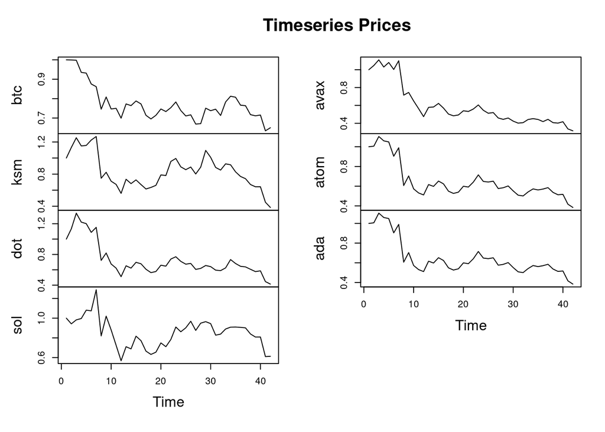

All prices are normalized to 1 for the first day. The data shows, that KSM spiked around the 10th of June as a reaction to the announcement of the auctions (which were announced at the 8th of June). Generally, all coins lost significant value since the 25th of May and it is difficult to disentangle that general trend from the announcement of auctions. The next table shows how much value each coin lost since the 25th of May.

| Coin | Price change from day 25th May to 23rd June |
| --- | --- |
| BTC | -34.9907143 % |
| DOT | -58.6393175 % |
| KSM | -61.5133745 % |
| AVAX | -68.4573701 % |
| SOL | -38.7248182 % |
| ATOM | -61.6089257 % |
| ADA | -61.6089257 % |

If we take the 25th of May as reference date, we can see that KSM declined similar to other smaller cap coins (i.e., other than BTC). The next table shows the relative decline of the coins if we take the 10th of June as reference.

| Coin | Price change from day 10th June to 23rd June |
| --- | --- |
| BTC | -13.4365259 % |
| DOT | -36.9399816 % |
| KSM | -64.8530285 % |
| AVAX | -31.2496603 % |
| SOL | -36.4764908 % |
| ATOM | -36.2517222 % |
| ADA | -36.2517222 % |

**Result 1:**

- Compared to the situation of before auctions were imminent, KSM lost value comparable to the market.
- However, the announcement/start of the auctions shortly gave the KSM value momentum, which could not be sustained.
- This is backed by anecdotal evidence that good news are only providing sustainable rise in price if markets are bullish (or going sidewise). In bad market circumstances, price increases from good news cannot be sustained.

## Volume

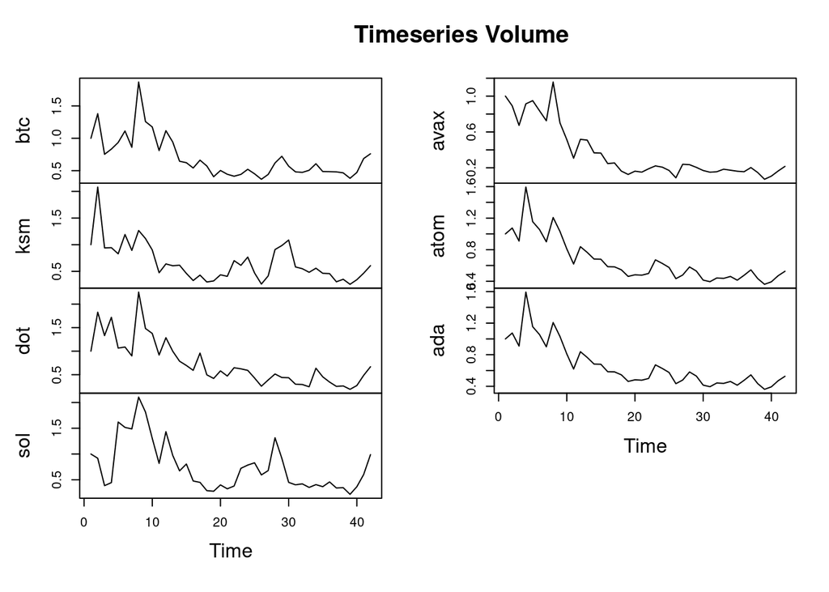

We can see that the volume of KSM spiked around the announcement but apart from that follow the general trend.

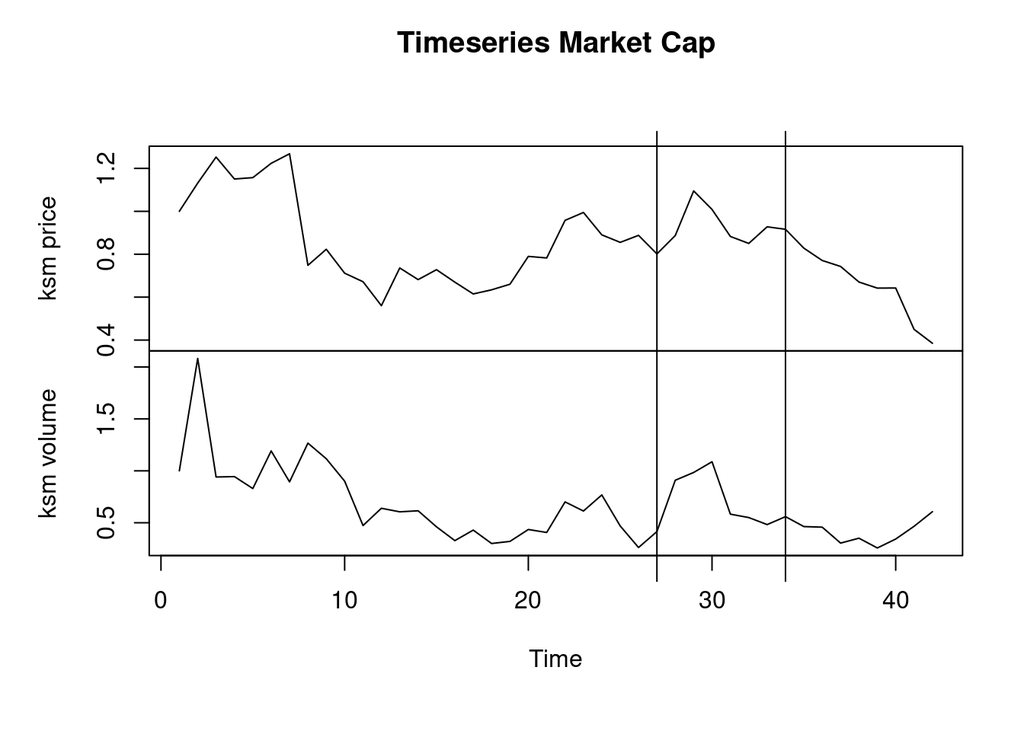

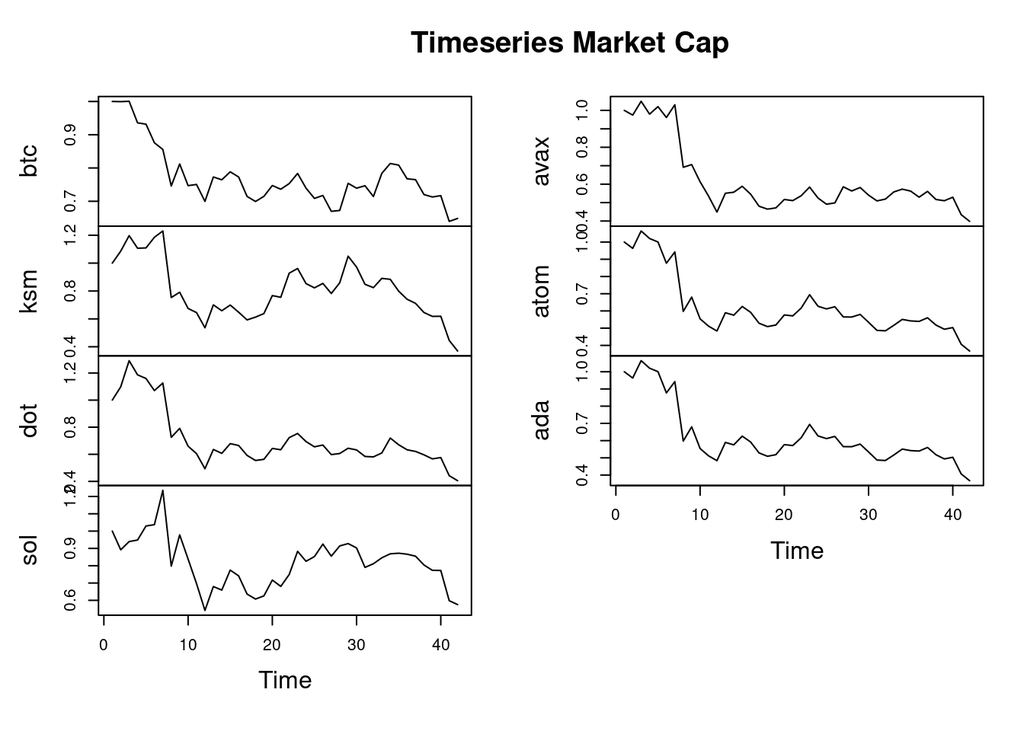

# Parametric Analysis

In order to find out whether the KSM price is driven by the BTC price, a common approach is to use a VAR model. However, this does assume that the timeseries is stationary. To test this, we use the Augmented Dickey-Fuller Test.

```
##
##  Augmented Dickey-Fuller Test
##
## data:  btc_timeseries
## Dickey-Fuller = -2.7545, Lag order = 3, p-value = 0.2762
## alternative hypothesis: stationary
```

```
##
##  Augmented Dickey-Fuller Test
##
## data:  ksm_timeseries
## Dickey-Fuller = -1.669, Lag order = 3, p-value = 0.7041
## alternative hypothesis: stationary
```

We cannot reject the H0 that both timeseries are non-stationary and therefore we cannot test with VAR.

## Granger Causality

An alternative to VAR is the Granger causality, which is more relaxed on the stationary assumptions. It tests whether one timeseries causally affects the other. In other words, does knowing the price of one asset have predictive power to estimate the price of the other asset. that tests whether one timeseries causally affects the other.

```
## Granger causality test
##
## Model 1: ksm ~ Lags(ksm, 1:3) + Lags(btc, 1:3)
## Model 2: ksm ~ Lags(ksm, 1:3)
##   Res.Df Df      F Pr(>F)
## 1     32
## 2     35 -3 0.7327 0.5402
```

We cannot reject the H0 that the price of BTC does not Granger-cause the price of KSM. This means that knowing the price of BTC at a certain lag has no predictive value on the price of KSM.

```
## Granger causality test
##
## Model 1: dot_timeseries ~ Lags(dot_timeseries, 1:3) + Lags(ksm_timeseries, 1:3)
## Model 2: dot_timeseries ~ Lags(dot_timeseries, 1:3)
##   Res.Df Df      F  Pr(>F)
## 1     32
## 2     35 -3 2.8407 0.05335 .
## ---
## Signif. codes:  0 '***' 0.001 '**' 0.01 '*' 0.05 '.' 0.1 ' ' 1
```

```
## Granger causality test
##
## Model 1: ksm_timeseries ~ Lags(ksm_timeseries, 1:3) + Lags(dot_timeseries, 1:3)
## Model 2: ksm_timeseries ~ Lags(ksm_timeseries, 1:3)
##   Res.Df Df      F Pr(>F)
## 1     32
## 2     35 -3 3.7588 0.0203 *
## ---
## Signif. codes:  0 '***' 0.001 '**' 0.01 '*' 0.05 '.' 0.1 ' ' 1
```

As a sidenote, it seems that the KSM and DOT price are causally linked with each other.

**Result 2:**

# Behavioral Network Data

## Staking Rate and Unstaking Dynamics

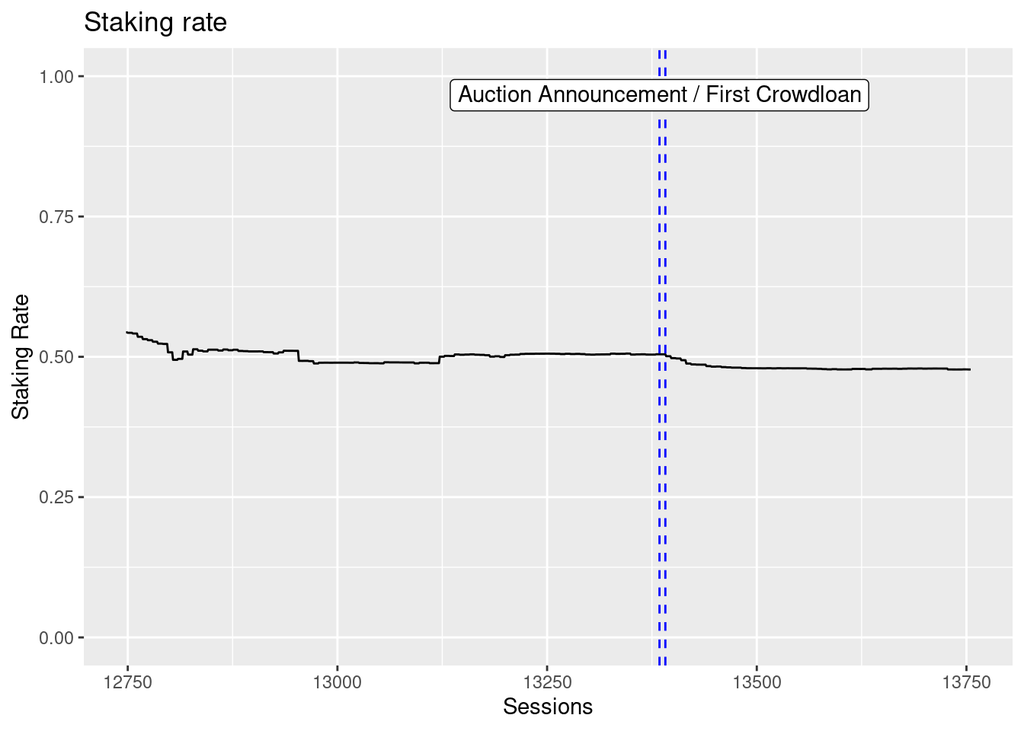

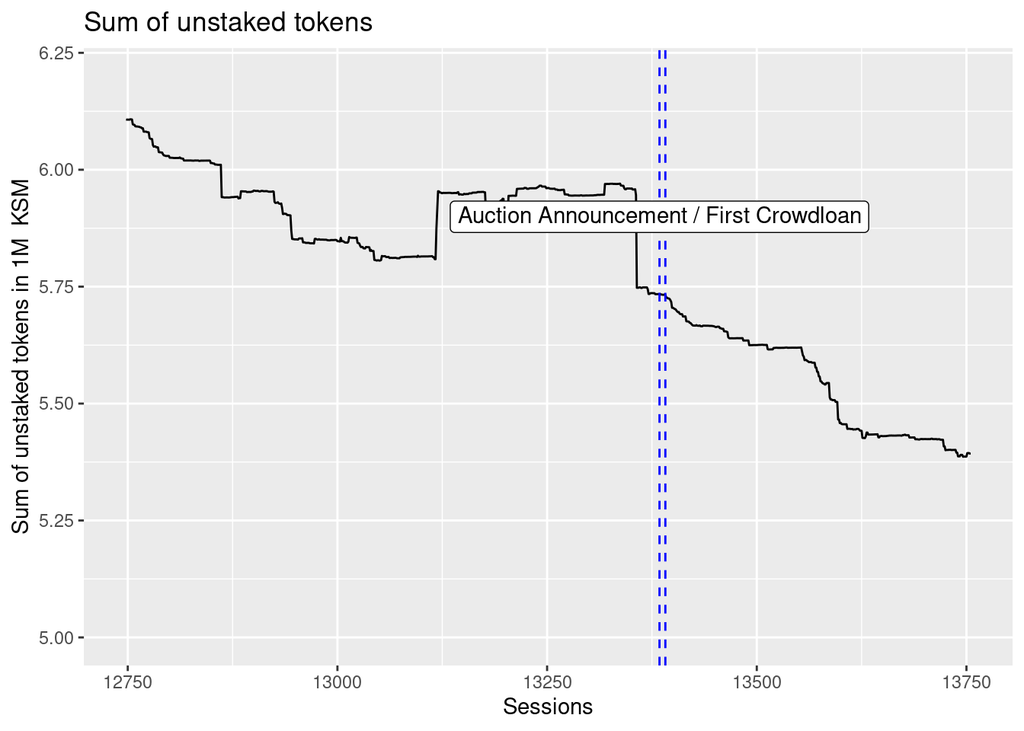

During the whole time of analysis, a total of 714444.6 KSM were unstaked.

We can observe that there has been a large amount of KSM withdrawn at once between session 13356 and 13357. Upon further inspection, it seems that this has largely be caused by a single entity.

[output not shown]

## Parametric Analysis

In this section, we can try to predict the number of unstaked tokens with the price as we did before with the BTC price on the KSM price. Now, the question is whether the timeseries of unstaked tokens have causal effect on the price.

```
## Granger causality test
##
## Model 1: ksm_price ~ Lags(ksm_price, 1:1) + Lags(staked_amount, 1:1)
## Model 2: ksm_price ~ Lags(ksm_price, 1:1)
##   Res.Df Df     F  Pr(>F)
## 1     38
## 2     39 -1 4.136 0.04901 *
## ---
## Signif. codes:  0 '***' 0.001 '**' 0.01 '*' 0.05 '.' 0.1 ' ' 1
```

The statistical test is significant which means, that we can reject the H0 that the unstaking behavior does not influence the price of KSM. The reverse is not true (p < 0.2946). This requires further investigation.

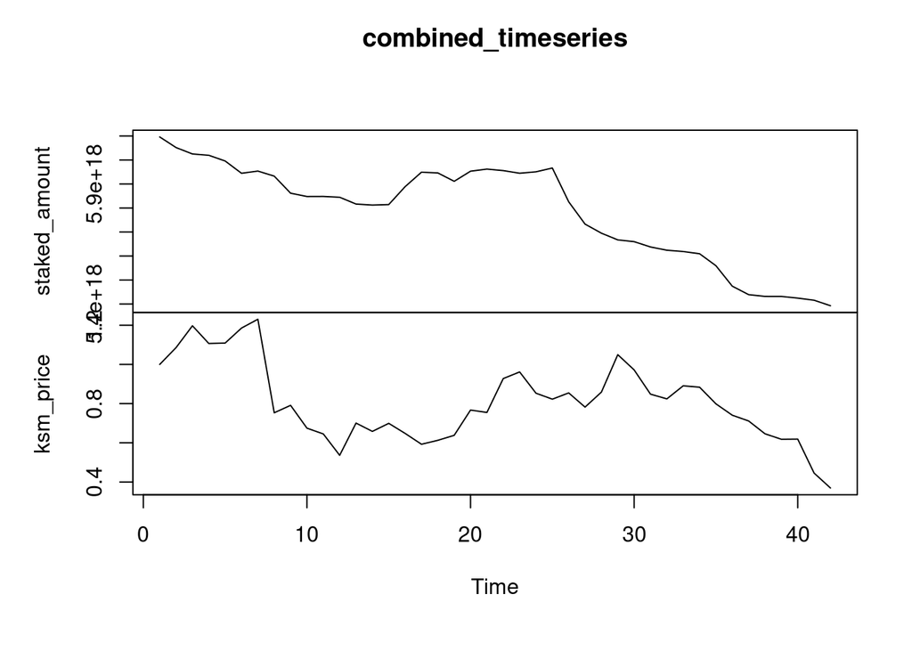

**Result 3:**

- The staking rate only decreased by a few percent in response to the announcement of the auction.
- This might be due to the fact that the staking rate is already far from the optimal (75%) and therefore staking remains quite attractive.
- A large unstaking event can be observed where a potential exchange unstaked in order to provide liquidity for crowdloan contributions of their customers.
- A statistical test suggests that the unstaking dynamics actually has some causal effect on the price development of KSM.

# Crowdloan Data

## Crowdloan contributions

The following table shows the number of KSM contributed to each project (up until block 8042451).

| Name | Contribution |
| --- | --- |
| Karura | 501365.5 |
| Khala | 18006.22 |
| Bifrost | 20711.68 |
| Shiden | 92664.19 |
| Moonriver | 142413.8 |
| Darwinia | 2277.994 |

## Stake to contributions

The following analysis tracks the accounts that unstaked KSM in the respective period and compares them with those accounts contributing to crowdloans. We make the strong assumption, that everything that has been unbonded and not yet contributed might be used to sell.

The total number of unstaked tokens in the whole period is 714444.6 KSM. This consists of a total number of 1010515 unstaked tokens and 296070.9 restaked tokens. As we observed before, 198180 KSM were unstaked of an exchange in order to offer liquidity for users. As those tokens are custodials, we exclude them from the analysis (as they are not clearly used to sell or to contribute to crowdloans).

We can argue that 157930.6 of the total number of unstaked tokens went into crowdloans. This involves the assumption, that an account that unstaked tokens and contributed to a crowdloan used those tokens.

The ratio of unstaked tokens (without that of the exchange) to crowdloan contribution is 30.59%. It has to be noted that this is potentially the lower bound. For example, a user unstaking their tokens, sending them to another account and contributing from there would not be tracked here.

The amount of tokens from the total unstaking during the period which are still liquid and could be sold are those tokens that have not yet been restaked, not contributed to the crowdloan and are not in possession of that one large exchange. This sums up to: 62263.1 KSM.

**Result 4:**

- A significant amount of tokens has been contributed to crowdloans.
- Most contributions concentrate on Karura.
- An estimate suggests that only around 30.59% of unstaked tokens went into crowdloans. The remaining tokens are either still liquid for further contributions or are sold (or hold without using them).

# Conclusion

The crypto-market is experiencing a bear market that negatively affects all prices. As seen in the tables above, KSM suffered similar price decrease than those of competitors. However, there was a period around the announcement that increased the price significantly. Taken the first day of analysis as reference point, KSM is at a similar standing as other crypto-currencies. But, it is clear that the momentum of the announcement diminished and did not contribute to a sustained value.

Parametric analysis of the unstaking behavior on the price revealed that there is some pressure coming from people who unstaked. This needs to be taken into consideration when making the announcement on Polkadot. Crucially, the longer unstaking period could help reduce the pressure on the price, because liquidity is coming more slowly to the market (compared to a price increase from the announcement). An optimal (but unlikely to be implemented option) would be to directly contribute staked tokens.

**Things to consider for Polkadot:** * Try to time the announcement / conduction of auctions with a good market situation (either bull market or at least accumulation phase (side-trend)).